# Pokus

# Sociologie (júlový turnus)

Zpět na rozcestník zpětné vazby | Tento report we Wordu | Data v CSV

## Hodnocení kurzu

Průměrná známka:

| Blok setkání | Průměrná známka |
| --- | --- |
| A | 1.38 |

### Hodnocení po dnech

A a B jsou bloky (A je 9-10:30, B je 11-12:30)

Známky jsou jako ve škole: 1 je nejlepší, 5 nejhorší

[interactive chart not shown]

### Co se na kurzu líbilo

- Diskusie, pretoze tam sa prejavia nase nazory a clovek sa pocas nich preberie navyse nase diskusie boli casto velmi zaujimave.
- NNH - bolo to nieco nove
- Zajimava temata hodin a dobre diskuze
- Na kurze Sociológie sa mi najviac páčilo, že som sa mohla slobodne vyjadriť na ľubovoľnú tému. Diskusie na tomto kurze boli super.
- Discusie, dalo mi to nový pohlad na vec.
- Možnost strávit skoro celou hodinu diskusí jak s Markétou, tak s ostatními účastníky (některými z nich). Zároveň některá témata, hlavně nerovnosti, sociální stát a statistika.
- Vďaka týmto kurzom, som Sociológiu vyškrtla zozoznamu potencionálnych vysokých škol… Kurzy pripravené na vysokej úrovni. Markétka je skvwlá, ale s témou samotnom sme si nesadli.
- všetky témy boli zaujímavé, bavili ma diskusie, kt. mohlo byť viac najviac s ami páčila téma sociální stát

### Co na kurzu změnit

- Ja si myslim ze som dala Marketke dostatocny feedback a hlavne je aby ona vedela co by sa mozno mohlo zlepsit.
- viac tém, ktoré sa bežne nediskutujú
- Nejake materialy dopredu, abychom se mohli seznamit s tematy, o kterych jsme diskutovali, uz pred discoverem
- Nešla by som hlavne poďla prezentácii, viacej sa mi páčili videá a konkrétne príklady.
- Nič.
- Některá témata, třeba hned první (předsudky), bych pojal trochuv více teoreticky - strávit 90 minut diskusí o tom, že předsudky jsou špatné a že ne všichni Romové jsou zlí je určitě důležité, ale myslím si, že každý z nás to už slyšel mnohokrát. Ocenil bych např. další statistiky, teorie, proč a jak předsudky fungují apod.

## Hodnocení lektora

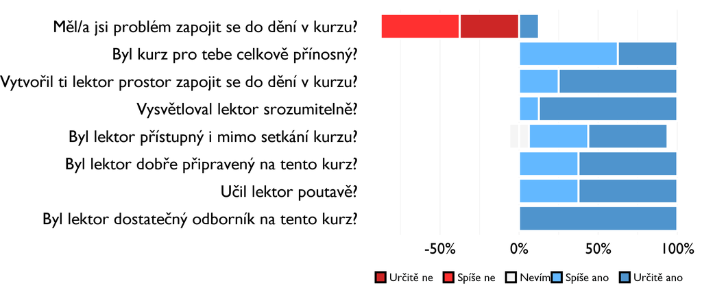

### Komentáře k lektorovi

- Viac diskusii, problemov, experimentov ktore by sme robili na nas samych
- Bola si super !
- Markéta byla skvělá!
- Lektorka by mohla pri výklade obmedziť používanie častice hmmmmm počas premýšľania na minimum,

## Náročnost kurzu

### **Jak hodnotíš náročnost…**

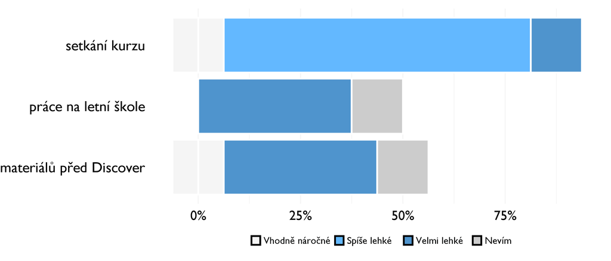

## Didaktika

Na některé otázky jsme se na augustovém turnuse neptali - tam uvidíte nadpis bez grafu.

### Jak lektor učí a měl by to změnit?

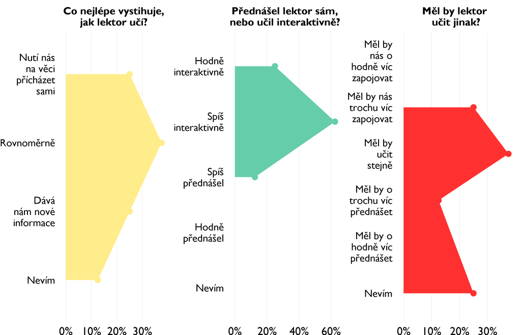

### Jak se studentům nejlépe učí?

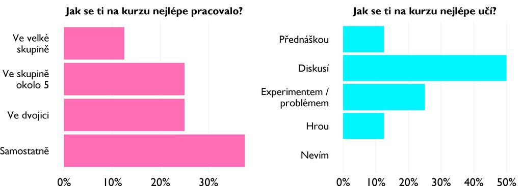

## Ovlivnil tě kurz nějak?

**Pokud ano, jak? Pokud ne, proč ne?**

- Nie pretoze mam velmi vyhranene nazory a ujasnenu buducnost
- nové pohěady
- Ukazal mi, ze i kdyz me spolecenske vedy hodne zajimaji, asi se jim nebudu chtit venovat na univerzite
- Utvrdilo ma to v tom , že chcem ísť študovať, niečo spojené so sociológiou.
- Nový pohlad na vec.
- Dozvěděl jsem se, co to vlastně sociologie je, což oceňuji. Zároveň jsem pochopil, jak funguje statistika a mnoho dalších už spíše dílčích informací, které mi pomohly doplnit můj obraz o oblastech jako náboženská hnutí.
- Ovplzvnil ma pri výbere vysokej školy. Na sociológiu nepojdem i keď kurz bol spracovaný perfektne.
- dodal mi nové pohľady na dianie v spoločnosti